# DataVisualizationFinal

**Fundamentals of Data Visualization Final Project**

1. **Dataset Overview and Source**

For my project, I have chosen the Superstore dataset, which is widely used in data analytics demonstrations. It simulates sales data for a retail store covering multiple product categories, regions, and time periods. You can find various versions of this dataset on sites like [Tableau](https://community.tableau.com/s/question/0D54T00000CWeX8SAL/sample-superstore-sales-excelxls).

Most versions of this dataset span multiple years (2014–2017) and include around 10,000 rows. This makes it a moderately sized, tabular dataset—complex enough to yield interesting insights. Due to Altairs row limitations most of my exploration will be done with aggegrate data.

2. **Goals and Key Questions**

*Overall Goal:*

My primary goal is to understand sales performance and profitability across different product categories, sub-categoires and states.

*Specific Questions:*

- What correlations exist within our data that are strongly linked to sales and profit?
  - **Answer analysis and code to support assertion found below:** Based on the creation of correlation matrix's and heatmaps, this data does not have any "Strong Correlation" the strongest correlation we have is between sales and profit (.48 correlation) which would be considered a moderate correlation.
- Which product categories and sub-categories yield the highest sales and profit?
  - **Answer analysis and code to support assertion found below:** The category with the highest profit is "Technology" and the highest profitable sub-category is "Copiers".
- What states account for the most sales and profit?
  - **Answer analysis and code to support assertion found below:** Based on the analysis below the top 3 most profitable states are: California, New York and Washington.
3. **Key Elements of Design**

All of my visualizations had to do with 'profit' as such I chose to focus on a simple and intutive color scheme. If a category, subcategory or state was profitable it green and if it was not profitable it is red. For more consumers this is inline with what they would assume and allows for easier digestion of the visualizations.

4. **Evaluation of Approach**

I evaluated my deisgn choice with several non-technical family members to see if my approach was simple and approachable. Based on my straigh forward design choices they were all able to accurately and quickly understand the data presented.

5. **Synthesis of Findings**

Overall, my approach was effective—I efficiently completed my core objective. However, I recognize that this dataset offers virtually limitless insights. In the future, I plan to conduct a more comprehensive analysis to uncover additional trends and conclusions. For now, I focused on a targeted analysis due to time constraints.

**Importing Libraries and preliminary EDA**

```python
# Importing libraries that are likely to be used
import altair as alt
import numpy as np
import pandas as pd
import seaborn as sns
import matplotlib.pyplot as plt
import plotly.express as px
import ipywidgets as widgets
from ipywidgets import interact
```

```python
#Importing and viewing top row to show columns
df = pd.read_excel(r"\Users\peige\OneDrive\Desktop\MS DS\Fundamentals of Data Viz\Sample - Superstore (1).xls")

df.head(1)
```

|  | Row ID | Order ID | Order Date | Ship Date | Ship Mode | Customer ID | Customer Name | Segment | Country | City | ... | Postal Code | Region | Product ID | Category | Sub-Category | Product Name | Sales | Quantity | Discount | Profit |
| --- | --- | --- | --- | --- | --- | --- | --- | --- | --- | --- | --- | --- | --- | --- | --- | --- | --- | --- | --- | --- | --- |
| 0 | 1 | CA-2016-152156 | 2016-11-08 | 2016-11-11 | Second Class | CG-12520 | Claire Gute | Consumer | United States | Henderson | ... | 42420 | South | FUR-BO-10001798 | Furniture | Bookcases | Bush Somerset Collection Bookcase | 261.96 | 2 | 0.0 | 41.9136 |

1 rows × 21 columns

```python
df.describe()
```

|  | Row ID | Order Date | Ship Date | Postal Code | Sales | Quantity | Discount | Profit |
| --- | --- | --- | --- | --- | --- | --- | --- | --- |
| count | 9994.000000 | 9994 | 9994 | 9994.000000 | 9994.000000 | 9994.000000 | 9994.000000 | 9994.000000 |
| mean | 4997.500000 | 2016-04-30 00:07:12.259355648 | 2016-05-03 23:06:58.571142912 | 55190.379428 | 229.858001 | 3.789574 | 0.156203 | 28.656896 |
| min | 1.000000 | 2014-01-03 00:00:00 | 2014-01-07 00:00:00 | 1040.000000 | 0.444000 | 1.000000 | 0.000000 | -6599.978000 |
| 25% | 2499.250000 | 2015-05-23 00:00:00 | 2015-05-27 00:00:00 | 23223.000000 | 17.280000 | 2.000000 | 0.000000 | 1.728750 |
| 50% | 4997.500000 | 2016-06-26 00:00:00 | 2016-06-29 00:00:00 | 56430.500000 | 54.490000 | 3.000000 | 0.200000 | 8.666500 |
| 75% | 7495.750000 | 2017-05-14 00:00:00 | 2017-05-18 00:00:00 | 90008.000000 | 209.940000 | 5.000000 | 0.200000 | 29.364000 |
| max | 9994.000000 | 2017-12-30 00:00:00 | 2018-01-05 00:00:00 | 99301.000000 | 22638.480000 | 14.000000 | 0.800000 | 8399.976000 |
| std | 2885.163629 | NaN | NaN | 32063.693350 | 623.245101 | 2.225110 | 0.206452 | 234.260108 |

```python
df.info()
```

```
<class 'pandas.core.frame.DataFrame'>
RangeIndex: 9994 entries, 0 to 9993
Data columns (total 21 columns):
 #   Column         Non-Null Count  Dtype
---  ------         --------------  -----
 0   Row ID         9994 non-null   int64
 1   Order ID       9994 non-null   object
 2   Order Date     9994 non-null   datetime64[ns]
 3   Ship Date      9994 non-null   datetime64[ns]
 4   Ship Mode      9994 non-null   object
 5   Customer ID    9994 non-null   object
 6   Customer Name  9994 non-null   object
 7   Segment        9994 non-null   object
 8   Country        9994 non-null   object
 9   City           9994 non-null   object
 10  State          9994 non-null   object
 11  Postal Code    9994 non-null   int64
 12  Region         9994 non-null   object
 13  Product ID     9994 non-null   object
 14  Category       9994 non-null   object
 15  Sub-Category   9994 non-null   object
 16  Product Name   9994 non-null   object
 17  Sales          9994 non-null   float64
 18  Quantity       9994 non-null   int64
 19  Discount       9994 non-null   float64
 20  Profit         9994 non-null   float64
dtypes: datetime64[ns](2), float64(3), int64(3), object(13)
memory usage: 1.6+ MB
```

Question 1: What correlations exist within our data that are strongly linked to sales and profit?

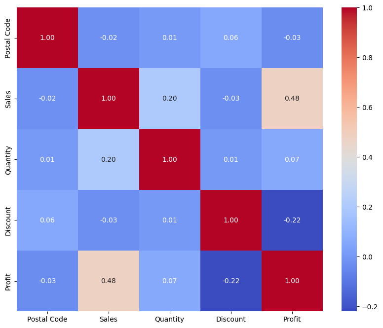

```python
#Creating a heatmap to identify correlations between numeric variables
numeric_df = df.select_dtypes(include='number').drop(columns=['Row ID'])
corr_matrix = numeric_df.corr()

plt.figure(figsize=(10,8))
heatmap = sns.heatmap(corr_matrix, annot=True, cmap='coolwarm', fmt='.2f')
plt.show()
```

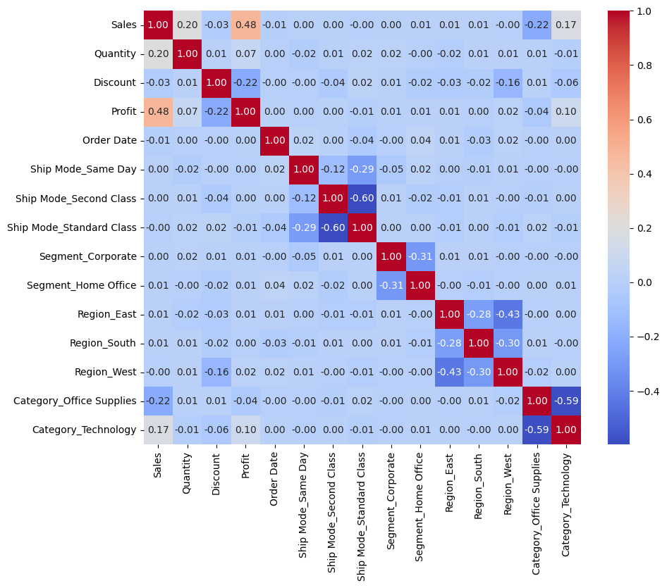

```python
# Encoding categorical data to view correlations
df_dummies = pd.get_dummies(df[['Order Date', 'Ship Mode', 'Segment', 'Region', 'Category']], drop_first=True)

numeric_df = df.select_dtypes(include='number').drop(columns=['Row ID', 'Postal Code'])
combined_df = pd.concat([numeric_df, df_dummies], axis=1)
corr_matrix = combined_df.corr()

plt.figure(figsize=(10, 8))
heatmap = sns.heatmap(corr_matrix, annot=True, cmap='coolwarm', fmt='.2f')
plt.show()
```

```python
#Since Altair has a 5000 row limit ill have to take a sample of my data
sample = df.sample(n=3000, random_state=42)

selector = alt.selection_point(fields=['Profit'], on='mouseover', nearest=True, bind='legend')

chart = alt.Chart(sample).mark_point().encode(
    x='Profit',
    y='Sales',
    tooltip=['Sales', 'Profit'],
    color=alt.condition('datum.Profit < 0', alt.value('red'), alt.value('green')),
    opacity=alt.condition(selector, alt.value(1), alt.value(0.3)),
    size=alt.Size('Profit').scale(range=[10, 150])
).add_params(
    selector
).properties(
    height=300,
    width=600,
    title=alt.TitleParams(
        text='Correlation between sales and profit',
        subtitle='Red indicates negative profit while green indicates positive profit',
        fontSize=20,
        subtitleFontSize=14
            )
).interactive()

chart
```

[interactive chart not shown]

[figure not shown]

Based on the creation of correlation matrix's and heatmaps, this data does not have any "Strong Correlation" the strongest correlation we have is between sales and profit (.48 correlation) which would be considered a moderate correlation.

Question 2: Which product categories and sub-categories yield the highest sales and profit?

```python
#Determining categories with highest sales and profit
category_query = (
    df.groupby('Category', as_index=False)
    .agg({'Profit': 'sum', 'Sales': 'sum'})
    .sort_values('Profit', ascending= False))

category_query = category_query.reset_index(drop=True)
category_query.index = category_query.index + 1
category_query.index.name = 'Rank'

category_query['Profit Margin'] = ((category_query['Profit'] / category_query['Sales']) *100)

for col in ['Profit', 'Sales']:
    category_query[col] = category_query[col].apply(lambda x: f"${x:.2f}")

category_query['Profit Margin'] = category_query['Profit Margin'].apply(lambda x: f"{x:.2f}%")

title = "Profit, Sales & Profit Margin by Category"
centered_title = title.center(55)
bold_centered_title = f"\033[1m{centered_title}\033[0m"
print(bold_centered_title)

category_query.style
```

```
       Profit, Sales & Profit Margin by Category
```

| Rank | Category | Profit | Sales | Profit Margin |
| --- | --- | --- | --- | --- |
| 1 | Technology | $145454.95 | $836154.03 | 17.40% |
| 2 | Office Supplies | $122490.80 | $719047.03 | 17.04% |
| 3 | Furniture | $18451.27 | $741999.80 | 2.49% |

```python
#Creating interactive chart for highest profit categories
# Creating interactive chart for highest profit categories
import ipywidgets as widgets
from ipywidgets import interact
import plotly.express as px  # assuming this is already installed

cat_data = (
    df.groupby('Category', as_index=False)
      .agg({'Sales': 'sum', 'Profit': 'sum'})
      .sort_values('Profit', ascending=False)
)

custom_scale = [(0.0, 'red'), (0.5, 'white'), (1.0, 'green')]

widget = interact(
    lambda Top: (
        px.bar(
            cat_data[:Top],
            x='Category',
            y='Profit',
            color='Profit',
            labels={'Category': "Product Category", 'Profit': 'Total Profit'},
            template='plotly_dark',
            text='Profit',
            color_continuous_scale=custom_scale,
            color_continuous_midpoint=0
        )
        .update_layout(
            xaxis_tickangle=-45,
            yaxis={'visible': True, 'showticklabels': True, 'showgrid': False},
            font=dict(size=12)
        )
        .update_traces(
            showlegend=False,
            texttemplate='$%{y:.2f}',
            textposition='auto'
        )
    ),
    Top=widgets.IntSlider(min=1, max=len(cat_data), step=1, value=3)
)
```

```
interactive(children=(IntSlider(value=3, description='Top', max=3, min=1), Output()), _dom_classes=('widget-in…
```

[figure not shown]

```python
#Determining sub-categories with highest sales and profit
subquery = (df.groupby('Sub-Category', as_index= False)
            .agg({'Profit':'sum', 'Sales':'sum'})
            .sort_values('Profit', ascending= False)
            )

subquery = subquery.reset_index(drop= True)
subquery.index = subquery.index +1
subquery.index.name = 'Rank'

subquery['Profit Margin'] = ((subquery['Profit'] / subquery['Sales']) * 100).apply(lambda x: f"{x:.2f}%")

for col in ['Profit', 'Sales']:
    subquery[col] = subquery[col].apply(lambda x: f"${x:.2f}")

title = "Profit, Sales & Profit Margin by Sub-Category"
centered_title = title.center(55)
bold_centered_title = f"\033[1m{centered_title}\033[0m"
print(bold_centered_title)

subquery.style
```

```
     Profit, Sales & Profit Margin by Sub-Category
```

| Rank | Sub-Category | Profit | Sales | Profit Margin |
| --- | --- | --- | --- | --- |
| 1 | Copiers | $55617.82 | $149528.03 | 37.20% |
| 2 | Phones | $44515.73 | $330007.05 | 13.49% |
| 3 | Accessories | $41936.64 | $167380.32 | 25.05% |
| 4 | Paper | $34053.57 | $78479.21 | 43.39% |
| 5 | Binders | $30221.76 | $203412.73 | 14.86% |
| 6 | Chairs | $26590.17 | $328449.10 | 8.10% |
| 7 | Storage | $21278.83 | $223843.61 | 9.51% |
| 8 | Appliances | $18138.01 | $107532.16 | 16.87% |
| 9 | Furnishings | $13059.14 | $91705.16 | 14.24% |
| 10 | Envelopes | $6964.18 | $16476.40 | 42.27% |
| 11 | Art | $6527.79 | $27118.79 | 24.07% |
| 12 | Labels | $5546.25 | $12486.31 | 44.42% |
| 13 | Machines | $3384.76 | $189238.63 | 1.79% |
| 14 | Fasteners | $949.52 | $3024.28 | 31.40% |
| 15 | Supplies | $-1189.10 | $46673.54 | -2.55% |
| 16 | Bookcases | $-3472.56 | $114880.00 | -3.02% |
| 17 | Tables | $-17725.48 | $206965.53 | -8.56% |

```python
#Creating interactive chart for highest profit sub-categories
cat_data = (
    df.groupby('Sub-Category', as_index=False)
      .agg({'Sales': 'sum', 'Profit': 'sum'})
      .sort_values('Profit', ascending=False)
)

custom_scale = [(0.0, 'red'), (0.5, 'white'), (1.0, 'green')]

widget = interact(
    lambda Top: (
        px.bar(
            cat_data[:Top],
            x='Sub-Category',
            y='Profit',
            color='Profit',
            labels={'Sub-Category': "Product Sub-Category", 'Profit': 'Total Profit'},
            template='plotly_dark',
            text='Profit',
            color_continuous_scale=custom_scale,
            color_continuous_midpoint=0
        )
        .update_layout(
            xaxis_tickangle=-45,
            yaxis={'visible': True, 'showticklabels': True, 'showgrid': False},
            font=dict(size=12)
        )
        .update_traces(
            showlegend=False,
            texttemplate='$%{y:.2f}',
            textposition='auto'
        )
        .show()
    ),
    Top=widgets.IntSlider(min=1, max=len(cat_data), step=1, value=3)
)
```

```
interactive(children=(IntSlider(value=3, description='Top', max=17, min=1), Output()), _dom_classes=('widget-i…
```

The category with the highest profit is "Technology" and the highest profitable sub-category is "Copiers".

Question 3: What states account for the most sales and profit?

```python
state = (df.groupby('State', as_index= False)
         .agg({'Profit':'sum', 'Sales':'sum'})
         .sort_values('Profit', ascending= False)).head()

state = state.reset_index(drop= True)
state.index += 1
state.index.name = 'Rank'

state['Profit Margin'] = ((state['Profit'] / state['Sales']) * 100).apply(lambda x: f"{x:.2f}%")

for col in ['Profit', 'Sales']:
    state[col] = state[col].apply(lambda x: f"${x:.2f}")

title = 'Sales, Profit and Profit Margin by State'
centered_title = title.center(55)
bold_centered_title = f"\033[1m{centered_title}\033[0m"
print(bold_centered_title)

state.style
```

```
        Sales, Profit and Profit Margin by State
```

| Rank | State | Profit | Sales | Profit Margin |
| --- | --- | --- | --- | --- |
| 1 | California | $76381.39 | $457687.63 | 16.69% |
| 2 | New York | $74038.55 | $310876.27 | 23.82% |
| 3 | Washington | $33402.65 | $138641.27 | 24.09% |
| 4 | Michigan | $24463.19 | $76269.61 | 32.07% |
| 5 | Virginia | $18597.95 | $70636.72 | 26.33% |

```python
#Creating interactive chart for highest profit sub-categories
state_data = (df.groupby('State', as_index= False)
         .agg({'Profit':'sum', 'Sales':'sum'})
         .sort_values('Profit', ascending= False))


custom_scale = [(0.0, 'red'), (0.5, 'white'), (1.0, 'green')]

widget = interact(
    lambda Top: (
        px.bar(
            state_data [:Top],
            x='State',
            y='Profit',
            color='Profit',
            labels={'State': "State", 'Profit': 'Total Profit'},
            template='plotly_dark',
            text='Profit',
            color_continuous_scale=custom_scale,
            color_continuous_midpoint=0
        )
        .update_layout(
            xaxis_tickangle=-45,
            yaxis={'visible': True, 'showticklabels': True, 'showgrid': False},
            font=dict(size=12)
        )
        .update_traces(
            showlegend=False,
            texttemplate='$%{y:.2f}',
            textposition='auto'
        )
        .show()
    ),
    Top=widgets.IntSlider(min=1, max=len(state_data), step=1, value=3)
)
```

```
interactive(children=(IntSlider(value=3, description='Top', max=49, min=1), Output()), _dom_classes=('widget-i…
```

```python
import requests

state_data = df.groupby('State', as_index=False).agg({
    'Sales': 'sum',
    'Profit': 'sum'
})

url = "https://raw.githubusercontent.com/PublicaMundi/MappingAPI/master/data/geojson/us-states.json"
states_geojson = requests.get(url).json()

fig = px.choropleth_map(
    state_data,
    geojson=states_geojson,
    locations='State',
    featureidkey="properties.name",
    color='Profit',
    color_continuous_scale=[(0.0, 'red'), (0.5, 'white'), (1.0, 'green')],
    color_continuous_midpoint=0,
    map_style="carto-darkmatter",
    zoom=3,
    center={"lat": 37.0902, "lon": -95.7129},
    opacity=0.7,
    height=600,
    template='plotly_dark'
)

fig.update_layout(margin={"r":0,"t":0,"l":0,"b":0})
fig.show()
```

Based on the analysis above the top 3 most profitable states are: California, New York and Washington

```python
!voila --theme=dark DataVisualizationFinal.ipynb
```

```
^C
```